# 20.Population Parameter Estimation

With most experiments, the sample size is small relative to the parent population. A small sample size may be due to any number of reasons, such as the difficulty of performing the experiment (e.g., physic experiments), the data is just not available (e.g., medical trials), or simply the fact that why should you do more work then is needed. Whatever the reason, an idea of how the parent population behaves is still of interest. The task then becomes estimating the parent population based on the use of a particular sample. It is most common to estimate the population parameters $ \mu $ and $ \sigma $ based on the sample mean $ \bar x $ and standard deviation $ S $. In this case, the population parameters are assumed to be proportional to the sample parameters. In other words

$$ \mu \propto \bar x $$$$ \sigma \propto S $$

It is important to state that the population parameters are not equal to the sample parameters. They are simply related to the sample parameters in some manner. They are not equal because different samples from the population will produce different means and standard deviations. These two relationships, how the population mean and standard deviation are related to the sample mean and standard deviation, are developed below.

## Population Mean Estimation (Large Sample)

We want to estimate the population mean $ \mu $ in terms of the sample mean $ \bar x $. However, it is known that the sample mean $ \bar x $ will not necessarily be equal to the population mean $ \mu $. It is reasonable to assume that the sample mean $ \bar x $ will be in the same region of the population mean $ \mu $, given that a proper sample is collected. We can then say that the population mean $ \mu $ is equal to the sample $ \bar x $ with the addition of an uncertainty element $ \delta $. That is

$$ \mu = \bar x \pm \delta $$

This expression is stating that with a certain confidence level, the population mean $ \mu $ will fall between $ \bar x - \delta $ and $ \bar x + \delta $ or

$$ \bar x - \delta \le \mu \le \bar x + \delta $$

This interval (between $ \bar x - \delta $ and $ \bar x + \delta $) is known as the confidence interval. It is the interval for which, to a certain degree of confidence, the population mean $ \mu $ falls. The confidence level (often denoted as $ C.L. $) is the probability that the population mean $ \mu $ will fall within the confidence interval or

$$ C.L. = P \left( \bar x - \delta \le \mu \le \bar x - \delta \right) $$

Higher confidence is placed on a mean in a larger interval than a smaller one. For example, we might state that the mean is $ 11 \pm 5 $ with a $ 95 \% $ confidence or $ 11 \pm 3 $ with a $ 60 \% $ confidence. The confidence level $ C.L. $ is normally expressed in terms of the level of significance $ \alpha $. That is

$$ C.L. = 1 - \alpha $$

The various terms are shown in a diagram below in Figure 1.

Figure 1: Population Distribution Diagram

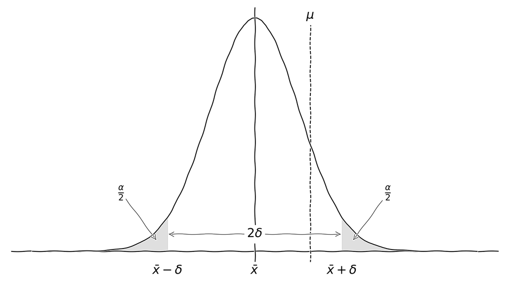

Shown in the plot is a normal distribution with a mean value of $ \bar x $. The confidence interval is $ 2 \delta $ with the two tails each being $ \frac{\alpha}{2} $. Some arbitrary population mean $ \mu $ is also shown. It is important to notice that the population mean $ \mu $ falls within the confidence interval.

The confidence interval on the population mean $ \mu $ may now be determined. It has been mentioned that it is reasonable to assume that the means of different samples taken from the same parent population will vary. Which brings us to the first of three conclusions of the [Central Limit Theorem](https://en.wikipedia.org/wiki/Central_limit_theorem).

**Central Limit Theorem Conclusion #1:**

1. If the parent population is normally distributed, the distribution of the sample means $ \bar x $'s will be normally distributed.

This first conclusion is useful when a particular random variable is normally distributed, but as it turns out, this is less common than one might think. Most things aren't normally distributed.

**Central Limit Theorem Conclusion #2:**

2. If the parent population is not normally distributed and the sample is size $ n $ is large ($ n \gt 30 $), the distribution of the sample means $ \bar x $'s will be normally distributed.

This second conclusion is why most things are thought to be normally distributed. It's not that they are normally distributed, but the samples taken from them are normally distributed. This second conclusion also leads to another important and useful point of the Central Limit Theorem. If the sample size $ n $ is large, then the standard deviation of the sample means $ \sigma_{\bar x} $ is given by

$$ \sigma_{\bar x} = \frac{\sigma}{\sqrt{n}} $$

where the sample standard deviation $ S $ is a good approximation of the population standard deviation $ \sigma $. For a large sample size, the confidence interval on the population mean $ \mu $ may then be estimated by the standard normal distribution transformation

$$ z = \frac{\bar x - \mu}{\sigma_{\bar x}} \approx \frac{\bar x - \mu}{\frac{S}{\sqrt{n}}} $$

Recall that the level of significance $ \alpha $ is the probability that the population mean $ \mu $ will fall outside the confidence interval. Thus for a two-tail situation (as in the case of a confidence interval), the boundary of the confidence interval is at $ -z_{\frac{\alpha}{2}} $ and $ z_{\frac{\alpha}{2}} $. This area may be seen graphically in Figure 2 below.

Figure 2: Standard Normal Distribution Diagram

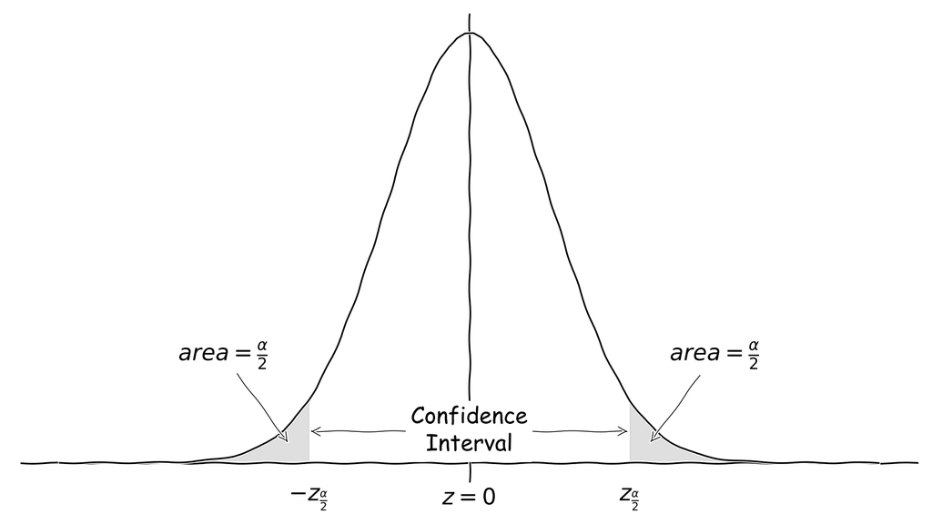

It can then be said that the probability that $ z $ will fall within the confidence interval is

$$ P\left( - z_{\frac{\alpha}{2}} \leq z \leq z_{\frac{\alpha}{2}} \right) = 1 - \alpha $$

Substituting the expression for $ z $ derived from the second conclusion of the Central Limit Theorem, the expression above becomes

$$ P\left( - z_{\frac{\alpha}{2}} \leq \frac{\bar x - \mu}{\frac{S}{\sqrt{n}}} \leq z_{\frac{\alpha}{2}} \right) = 1 - \alpha $$

Solving for the population mean $ \mu $ then shows

$$ P\left( \bar x - z_{\frac{\alpha}{2}} \frac{S}{\sqrt n} \leq \mu \leq \bar x + z_{\frac{\alpha}{2}} \frac{S}{\sqrt n} \right) = 1 - \alpha $$

Thus the interval associated with the population mean $ \mu $ for a large sample is

$$ \mu = \bar x \pm z_{\frac{\alpha}{2}} \frac{S}{\sqrt n} $$

with a confidence of $ 1 - \alpha $.

## Example Problem 1

**Given:**

A batch of resistors is made using a particular process. Based on $ 36 $ readings, the average resistance is $ 25 \Omega $, and the sample standard deviation is $ 0.5 \Omega $.

**Required:**

Determine the $ 90 \% $ confidence interval of the population mean $ \mu_R $.

**Solution:**

The sample size is

$$ n = 36 $$

The sample mean $ \bar R $ is

$$ \bar R = 25 \Omega $$

The sample standard deviation $ \sigma_R $ is

$$ \sigma_R = 0.5 \Omega $$

The confidence level $ C.L. $ is

$$ C.L. = 90 \% = 0.9 $$

Since the sample size is large ($ n \gt 30 $), the second conclusion of the Central Limit Theorem may be applied, and the confidence interval of the population mean $ \mu_R $ is given by

$$ \mu_R = \bar R \pm z_{\frac{\alpha}{2}} \frac{S}{\sqrt n} $$

The sample mean $ \bar R $, standard deviation $ \sigma_R $, and size $ n $ are all known. The only thing to be determined is the $ z_{\frac{\alpha}{2}} $ term. Using the standard normal table, the $ z_{\frac{\alpha}{2}} $ may be found using the confidence level $ C.L. $. Since the standard normal table as shown in 16.Normal Distribution is constructed using half the confidence level $ C.L. $, half the confidence level $ C.L. $ (i.e. $ 0.45 $) needs to be found in the table. A subsection of the standard normal table is shown below to aid the solution process.

| z | 0.0 | 0.01 | 0.02 | 0.03 | 0.04 | 0.05 | 0.06 | 0.07 | 0.08 | 0.09 |
| --- | --- | --- | --- | --- | --- | --- | --- | --- | --- | --- |
| 0.0 | 0.0000 | 0.0040 | 0.0080 | 0.0120 | 0.0160 | 0.0199 | 0.0239 | 0.0279 | 0.0319 | 0.0359 |
| 0.1 | 0.0398 | 0.0438 | 0.0478 | 0.0517 | 0.0557 | 0.0596 | 0.0636 | 0.0675 | 0.0714 | 0.0753 |
| $ \vdots $ | $ \vdots $ | $ \vdots $ | $ \vdots $ | $ \vdots $ | $ \vdots $ | $ \vdots $ | $ \vdots $ | $ \vdots $ | $ \vdots $ | $ \vdots $ |
| 1.5 | 0.4332 | 0.4345 | 0.4357 | 0.4370 | 0.4382 | 0.4394 | 0.4406 | 0.4418 | 0.4429 | 0.4441 |
| 1.6 | 0.4452 | 0.4463 | 0.4474 | 0.4484 | 0.4495 | 0.4505 | 0.4515 | 0.4525 | 0.4535 | 0.4545 |
| 1.7 | 0.4554 | 0.4564 | 0.4573 | 0.4582 | 0.4591 | 0.4599 | 0.4608 | 0.4616 | 0.4625 | 0.4633 |

From the table above, it may be seen that half the confidence level $ C.L. $ falls on the $ 1.6 $ row and in between the $ 0.04 $ and $ 0.05 $ columns. Thus,

$$ z_1 = 1.6 $$

The $ z_{\frac{\alpha}{2}} $ term is then

The confidence interval of the population mean $ \mu_R $ may now be found. The interval is shown below.

$$ \mu_R = \bar R \pm z_{\frac{\alpha}{2}} \frac{S}{\sqrt n} = 25\Omega \pm 1.645 \frac{0.5 \Omega}{\sqrt{36}} \approx 25 \pm 0.137 \Omega $$

## Population Mean Estimation (Small Sample)

The question now should be asked, "What if the sample size is less than $ 30 $? How is the population mean estimated then?" The third Central Limit Theorem conclusion answers this question.

**Central Limit Theorem Conclusion #3:**

This third conclusion is probably the most commonly used conclusion of the Central Limit Theorem regarding measurements. It is the case when the sample size $ n $ is not large. In this case, the assumption that the sample standard deviation $ S $ is a good approximation of the population standard deviation $ \sigma $ is no longer valid. The population standard deviation $ \sigma $ now has a degree of uncertainty associated with it. Due to uncertainty in the standard deviation, the confidence interval is expected to widen for the same confidence level. In these cases, the Student's distribution is to be used. The Student's distribution $ t $ value is given by

$$ t = \frac{\bar x - \mu}{\frac{S}{\sqrt n}} $$

A similar derivation as with the large sample size may now be done to estimate the confidence interval of the population mean $ \mu $. The probability that $ t $ will fall within the confidence interval is given by

$$ P\left( - t_{\frac{\alpha}{2}} \leq t \leq t_{\frac{\alpha}{2}} \right) = 1 - \alpha $$

for a given level of significance $ \alpha $. Substituting the expression for the Student's $ t $ value into the expression above yields

$$ P\left( - t_{\frac{\alpha}{2}} \leq \frac{\bar x - \mu}{\frac{S}{\sqrt n}} \leq t_{\frac{\alpha}{2}} \right) = 1 - \alpha $$

Solving for the population mean $ \mu $ shows

$$ P\left( \bar x - t_{\frac{\alpha}{2}} \frac{S}{\sqrt n} \leq \mu \leq \bar x + t_{\frac{\alpha}{2}} \frac{S}{\sqrt n} \right) = 1 - \alpha $$

Thus the interval associated with the population mean $ \mu $ for a small sample is

$$ \mu = \bar x \pm t_{\frac{\alpha}{2}} \frac{S}{\sqrt n} $$

with a confidence of $ 1 - \alpha $. This expression may seem like the previous expression developed, as in the case of a large sample size. However, the $ z $ and $ t $ values used in both cases will differ. The $ t $ value will always be larger than the $ z $ value for the same confidence level.

## Example Problem 2

**Given:**

A manufacturer of DVD systems would like to estimate a DVD brand's mean failure time with $ 95 \% $ confidence. Several systems are tested to failure, and the following data (in hours of playing time) are obtained.

$$ 1250 \mbox{,} \ 1320 \mbox{,} \ 1542 \mbox{,} \ 1464 \mbox{,} \ 1275 \mbox{, and} \ 1383 \ hrs $$

**Required:**

Estimate the $ 95 \% $ confidence interval on the mean.

**Solution:**

The confidence level $ C.L. $ is given as

$$ C.L. = 95 \% = 0.95 $$

The sample size $ n $ is given as

$$ n = 6 $$

The sample mean $ \bar T $ is calculated as

$$ \bar T = \sum_{i = 1}^n\frac{x_i}{n} = \frac{1250 + 1320 + 1542 + 1464 + 1275 + 1383}{6} hrs \approx 1372.3 hrs $$

To determine the confidence interval, the sample standard deviation $ S_T $ and the Student's $ t $ value at a confidence level $ C.L. $ of $ 95 \% $ must be found. The sample standard deviation is found by

$$ \begin{align} S_T &= \sum_{i = 1}^n \sqrt{\frac{\left(x_i - \bar x\right)^2}{n - 1}} \\ &= \sqrt{\frac{\left(1250 - 1372.3 \right)^2}{6 - 1} + \frac{\left(1320 - 1372.3 \right)^2}{6 - 1} + \frac{\left(1542 - 1372.3 \right)^2}{6 - 1} + \frac{\left(1464 - 1372.3 \right)^2}{6 - 1} + \frac{\left(1275 - 1372.3 \right)^2}{6 - 1} + \frac{\left(1383 - 1372.3 \right)^2}{6 - 1}} \\ &= 113.6 hrs \end{align} $$

Next, the Student $ t $ value may be found by first calculating the degrees of freedom $ \nu $ of the sample as

$$ \nu = n - 1 = 6 - 1 = 5 $$

The level of significance $ \alpha $ then needs to be determined by

$$ \alpha = 1 - C.L. = 1 - 0.95 = 0.05 $$

Half of the level of significance $ \frac{\alpha}{2} $ is then

$$ \frac{\alpha}{2} = \frac{0.05}{2} = 0.025 $$

The Student Distribution table found in 17.Student Distribution document may now be used to find the $ t $ value for the desired confidence level. A subsection of the table is shown below.

|  |  |  |  |  | $\frac{\alpha}{2}$ |  |  |  |  |
| --- | --- | --- | --- | --- | --- | --- | --- | --- | --- |
| $\nu$ | 0.25 | 0.2 | 0.1 | 0.05 | 0.025 | 0.02 | 0.01 | 0.005 | 0.001 |
| 1 | 1.000 | 1.376 | 3.078 | 6.314 | 12.706 | 15.895 | 31.821 | 63.657 | 318.309 |
| 2 | 0.816 | 1.061 | 1.886 | 2.920 | 4.303 | 4.849 | 6.965 | 9.925 | 22.327 |
| 3 | 0.765 | 0.978 | 1.638 | 2.353 | 3.182 | 3.482 | 4.541 | 5.841 | 10.215 |
| 4 | 0.741 | 0.941 | 1.533 | 2.132 | 2.776 | 2.999 | 3.747 | 4.604 | 7.173 |
| 5 | 0.727 | 0.920 | 1.476 | 2.015 | 2.571 | 2.757 | 3.365 | 4.032 | 5.893 |
| 6 | 0.718 | 0.906 | 1.440 | 1.943 | 2.447 | 2.612 | 3.143 | 3.707 | 5.208 |

Going to the row $ 5 $ for the degrees of freedom $ \nu $ and the column $ 0.025 $ for half the level of significance $ \frac{\alpha}{2} $, a $ t $ value is found. It is shown below.

$$ t_{\frac{\alpha}{2}} = 2.571 $$

The confidence interval of the population mean $ \mu_T $ may now be found. The interval is shown below.

$$ \mu_T = \bar T \pm t_{\frac{\alpha}{2}} \frac{S}{\sqrt n} = 1372.3 hrs \pm 2.571 \frac{113.6 hrs}{\sqrt{6}} \approx 1372.3 hrs \pm 119.2 hrs $$